# Nuclei Segmentation and Custom Binning of Visium HD Gene Expression Data

Tutorial is from 10x Genomics: https://www.10xgenomics.com/analysis-guides/segmentation-visium-hd

*Overview*

To generate custom nuclei-specific bins, we begin by segmenting a high-resolution H&E image to create a nuclei mask. Then we use the shape and location of each nucleus in the mask to sort barcodes into bins that correspond to each individual nucleus. Lastly, we perform gene-wise summation of UMI counts in each bin, resulting in a gene-by-binned barcode matrix.

This Analysis Guide employs StarDist for nuclei segmentation of mouse intestinal cells. A custom python script is then used to bin and sum the gene expression data based on the segmented nuclei mask. The resulting gene-by-binned barcode matrix is well-suited for visualization and downstream analyses such as clustering. All steps are conducted using the Python programming language. Although not explicitly discussed in this guide, this approach can be extended to other programming or scripting languages, including R.

```python
import tensorflow as tf
print("Num GPUs Available: ", len(tf.config.list_physical_devices('GPU')))

import pandas as pd
import numpy as np
import matplotlib.pyplot as plt
import anndata
import geopandas as gpd
import scanpy as sc

from tifffile import imread, imwrite
from csbdeep.utils import normalize
from stardist.models import StarDist2D
from shapely.geometry import Polygon, Point
from scipy import sparse
from matplotlib.colors import ListedColormap

from IPython.display import display, Image
import pickle
def get_picklable_objects(namespace):
    picklable = {}
    for name, obj in namespace.items():
        try:
            pickle.dumps(obj)  # Attempt to pickle the object
            picklable[name] = obj
        except (pickle.PicklingError, TypeError, AttributeError) as e:
            print(f"Skipping {name}: {e}")  # Log the error
            continue
    return picklable
```

[output not shown]

```
Num GPUs Available:  1
```

Data Visualization Helper Functions: We define functions to help with plotting results in the next code block.

```python
# General image plotting functions
def plot_mask_and_save_image(title, gdf, img, cmap, output_name=None, bbox=None):
    if bbox is not None:
        # Crop the image to the bounding box
        cropped_img = img[bbox[1]:bbox[3], bbox[0]:bbox[2]]
    else:
        cropped_img = img

    # Plot options
    fig, axes = plt.subplots(1, 2, figsize=(12, 6))

    # Plot the cropped image
    axes[0].imshow(cropped_img, cmap='gray', origin='lower')
    axes[0].set_title(title)
    axes[0].axis('off')

    # Create filtering polygon
    if bbox is not None:
        bbox_polygon = Polygon([(bbox[0], bbox[1]), (bbox[2], bbox[1]), (bbox[2], bbox[3]), (bbox[0], bbox[3])])
        # Filter for polygons in the box
        intersects_bbox = gdf['geometry'].intersects(bbox_polygon)
        filtered_gdf = gdf[intersects_bbox]
    else:
        filtered_gdf=gdf

    # Plot the filtered polygons on the second axis
    filtered_gdf.plot(cmap=cmap, ax=axes[1])
    axes[1].axis('off')
    axes[1].legend(loc='upper left', bbox_to_anchor=(1.05, 1))


    # Save the plot if output_name is provided
    if output_name is not None:
        plt.savefig(output_name, bbox_inches='tight')  # Use bbox_inches='tight' to include the legend
    else:
        plt.show()

def plot_gene_and_save_image(title, gdf, gene, img, adata, bbox=None, output_name=None):

    if bbox is not None:
        # Crop the image to the bounding box
        cropped_img = img[bbox[1]:bbox[3], bbox[0]:bbox[2]]
    else:
        cropped_img = img

    # Plot options
    fig, axes = plt.subplots(1, 2, figsize=(12, 6))

    # Plot the cropped image
    axes[0].imshow(cropped_img, cmap='gray', origin='lower')
    axes[0].set_title(title)
    axes[0].axis('off')

    # Create filtering polygon
    if bbox is not None:
        bbox_polygon = Polygon([(bbox[0], bbox[1]), (bbox[2], bbox[1]), (bbox[2], bbox[3]), (bbox[0], bbox[3])])


    # Find a gene of interest and merge with the geodataframe
    gene_expression = adata[:, gene].to_df()
    gene_expression['id'] = gene_expression.index
    merged_gdf = gdf.merge(gene_expression, left_on='id', right_on='id')

    if bbox is not None:
        # Filter for polygons in the box
        intersects_bbox = merged_gdf['geometry'].intersects(bbox_polygon)
        filtered_gdf = merged_gdf[intersects_bbox]
    else:
        filtered_gdf = merged_gdf

    # Plot the filtered polygons on the second axis
    filtered_gdf.plot(column=gene, cmap='inferno', legend=True, ax=axes[1])
    axes[1].set_title(gene)
    axes[1].axis('off')
    axes[1].legend(loc='upper left', bbox_to_anchor=(1.05, 1))

    # Save the plot if output_name is provided
    if output_name is not None:
        plt.savefig(output_name, bbox_inches='tight')  # Use bbox_inches='tight' to include the legend
    else:
        plt.show()

def plot_clusters_and_save_image(title, gdf, img, adata, bbox=None, color_by_obs=None, output_name=None, color_list=None):
    color_list=["#7f0000","#808000","#483d8b","#008000","#bc8f8f","#008b8b","#4682b4","#000080","#d2691e","#9acd32","#8fbc8f","#800080","#b03060","#ff4500","#ffa500","#ffff00","#00ff00","#8a2be2","#00ff7f","#dc143c","#00ffff","#0000ff","#ff00ff","#1e90ff","#f0e68c","#90ee90","#add8e6","#ff1493","#7b68ee","#ee82ee"]
    if bbox is not None:
        cropped_img = img[bbox[1]:bbox[3], bbox[0]:bbox[2]]
    else:
        cropped_img = img

    fig, axes = plt.subplots(1, 2, figsize=(12, 6))

    axes[0].imshow(cropped_img, cmap='gray', origin='lower')
    axes[0].set_title(title)
    axes[0].axis('off')

    if bbox is not None:
        bbox_polygon = Polygon([(bbox[0], bbox[1]), (bbox[2], bbox[1]), (bbox[2], bbox[3]), (bbox[0], bbox[3])])

    unique_values = adata.obs[color_by_obs].astype('category').cat.categories
    num_categories = len(unique_values)

    if color_list is not None and len(color_list) >= num_categories:
        custom_cmap = ListedColormap(color_list[:num_categories], name='custom_cmap')
    else:
        # Use default tab20 colors if color_list is insufficient
        tab20_colors = plt.cm.tab20.colors[:num_categories]
        custom_cmap = ListedColormap(tab20_colors, name='custom_tab20_cmap')

    merged_gdf = gdf.merge(adata.obs[color_by_obs].astype('category'), left_on='id', right_index=True)

    if bbox is not None:
        intersects_bbox = merged_gdf['geometry'].intersects(bbox_polygon)
        filtered_gdf = merged_gdf[intersects_bbox]
    else:
        filtered_gdf = merged_gdf

    # Plot the filtered polygons on the second axis
    plot = filtered_gdf.plot(column=color_by_obs, cmap=custom_cmap, ax=axes[1], legend=True)
    axes[1].set_title(color_by_obs)
    legend = axes[1].get_legend()
    legend.set_bbox_to_anchor((1.05, 1))
    axes[1].axis('off')

    # Move legend outside the plot
    plot.get_legend().set_bbox_to_anchor((1.25, 1))

    if output_name is not None:
        plt.savefig(output_name, bbox_inches='tight')
    else:
        plt.show()

# Plotting function for nuclei area distribution
def plot_nuclei_area(gdf,area_cut_off):
    fig, axs = plt.subplots(1, 2, figsize=(15, 4))
    # Plot the histograms
    axs[0].hist(gdf['area'], bins=50, edgecolor='black')
    axs[0].set_title('Nuclei Area')

    axs[1].hist(gdf[gdf['area'] < area_cut_off]['area'], bins=50, edgecolor='black')
    axs[1].set_title('Nuclei Area Filtered:'+str(area_cut_off))

    plt.tight_layout()
    plt.show()

# Total UMI distribution plotting function
def total_umi(adata_, cut_off):
    fig, axs = plt.subplots(1, 2, figsize=(12, 4))

    # Box plot
    axs[0].boxplot(adata_.obs["total_counts"], vert=False, widths=0.7, patch_artist=True, boxprops=dict(facecolor='skyblue'))
    axs[0].set_title('Total Counts')

    # Box plot after filtering
    axs[1].boxplot(adata_.obs["total_counts"][adata_.obs["total_counts"] > cut_off], vert=False, widths=0.7, patch_artist=True, boxprops=dict(facecolor='skyblue'))
    axs[1].set_title('Total Counts > ' + str(cut_off))

    # Remove y-axis ticks and labels
    for ax in axs:
        ax.get_yaxis().set_visible(False)

    plt.tight_layout()
    plt.show()
```

## 1 Nuclei Mask and GeoDataframe Creation

In the following code block, change the file path to the location of the high-resolution image. After importing the image, it is percentile normalized. Adjust the min and max percentile parameters as needed for other images by assessing the image mask for accuracy. Percentile normalization scales pixel values by the specified min and max percentiles.

```python
# Load the image file
# Change dir_base as needed to the directory where the downloaded example data is stored
dir_base = './240726_VisiumHD/'
filename = 'RJ_7_23_24.tif'
img = imread(dir_base + filename)

# Load the pretrained model
model = StarDist2D(None, name='2D_versatile_he', basedir='./')

# Percentile normalization of the image
# Adjust min_percentile and max_percentile as needed
min_percentile = 5
max_percentile = 95
img = normalize(img, min_percentile, max_percentile)
```

```
2024-10-08 10:57:10.008291: I tensorflow/core/common_runtime/gpu/gpu_device.cc:2021] Created device /job:localhost/replica:0/task:0/device:GPU:0 with 21791 MB memory:  -> device: 0, name: NVIDIA GeForce RTX 3090, pci bus id: 0000:01:00.0, compute capability: 8.6
```

```
Loading network weights from 'weights_best.h5'.
Loading thresholds from 'thresholds.json'.
Using default values: prob_thresh=0.692478, nms_thresh=0.3.
```

Execute the code block below to create the nuclei segmentation mask. This step has a long runtime and it will vary significantly depending on the chosen parameter settings. The nms threshold (`nms_thresh`) is set to a small number to reduce the probability of nuclei overlap. The `nms_thresh` parameter may require adjustment for different images. Also, it may be necessary to adjust the probability threshold (`prob_thresh`) for different images. Larger `prob_thresh` values will result in fewer segmented objects. The optimal values for `prob_thresh` and `nm_thresh` will depend on visual assessment of the nuclei segmentation mask.

```python
# Predict cell nuclei using the normalized image
# Adjust nms_thresh and prob_thresh as needed
labels, polys = model.predict_instances_big(img, axes='YXC', block_size=4096, prob_thresh=0.01,nms_thresh=0.001, min_overlap=128, context=128, normalizer=None, n_tiles=(4,4,1))
```

```
effective: block_size=(4096, 4096, 3), min_overlap=(128, 128, 0), context=(128, 128, 0)
```

[output not shown]

The function `predict_instances_big` divides the input image into blocks, processes them individually using `predict_instances`, and then combines the results.

In the next code block, we convert the results from *StarDist* into a *Geodataframe.* We will use the *Geodataframe* for barcode binning.

```python
# Creating a list to store Polygon geometries
geometries = []

# Iterating through each nuclei in the 'polys' DataFrame
for nuclei in range(len(polys['coord'])):

    # Extracting coordinates for the current nuclei and converting them to (y, x) format
    coords = [(y, x) for x, y in zip(polys['coord'][nuclei][0], polys['coord'][nuclei][1])]

    # Creating a Polygon geometry from the coordinates
    geometries.append(Polygon(coords))

# Creating a GeoDataFrame using the Polygon geometries
gdf = gpd.GeoDataFrame(geometry=geometries)
gdf['id'] = [f"ID_{i+1}" for i, _ in enumerate(gdf.index)]
```

To visualize the segmentation results, we will choose a region of interest from the high-resolution H&E image and define a bounding box. The bounding box delineates the boundaries of the region of interest. Selecting a smaller region of the image allows us to zoom in and inspect the segmentation of nuclei more carefully. In this demo we focus on one region, however, multiple regions should be inspected to determine if the normalization parameters and the model prediction parameters need further refinement.

[figure not shown]

Figure1: Fiji can be used to find the coordinates of a region of interest which is suitable for defining a bounding box.

Defining a bounding box involves specifying the coordinates for each corner. The ROI manager in Fiji is a convenient tool that can determine these coordinates. To get started, open the high-resolution image in Fiji. Next, use the rectangular selection tool to choose a region of interest (ROI). Once the ROI is created, follow these steps:

- 1. Navigate to the menu bar and select "Analyze" > "Tools" > "ROI Manager" > "Add [t]". Alternatively, use the shortcut Ctrl + T (Windows/Linux) or Cmd + T (Mac) to quickly open the ROI Manager. If the shortcut does not automatically add the ROI then select "Add [t]".
- 2. To view the coordinates, select "Properties" > "List Coordinates" and click "Ok". In the provided code, the bounding box argument (bbox) is entered as `(x min, y min, x max, y max)`.

The results for one region of interest from the nuclei segmentation are shown in below.

```
Clipping input data to the valid range for imshow with RGB data ([0..1] for floats or [0..255] for integers). Got range [-0.22962964..1.2888889].
2949323654.py (29): No artists with labels found to put in legend.  Note that artists whose label start with an underscore are ignored when legend() is called with no argument.
```

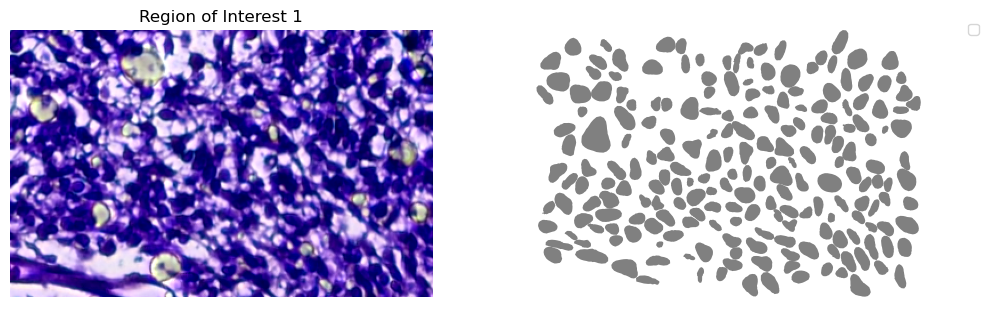

```python
# Plot the nuclei segmentation
# bbox=(x min,y min,x max,y max)
bbox=(5758,2664,6129,2898)
# Define a single color cmap
cmap=ListedColormap(['grey'])

# Create Plot
plot_mask_and_save_image(title="Region of Interest 1",gdf=gdf,bbox=bbox,cmap=cmap,img=img,output_name=dir_base+"image_mask.ROI1.tif")
```

Figure 2: Nuclei segmentation for one region of interest.

```python
picklable_vars = get_picklable_objects(globals())
with open("ipynb_workspace.pkl", "wb") as f:
    pickle.dump(picklable_vars, f)
```

[output not shown]

## 2 Binning Visium HD Gene Expression Data

```python
with open("ipynb_workspace.pkl", "rb") as f:
    picklable_vars = pickle.load(f)
globals().update(picklable_vars)
```

In the following code block, we load the 2x2 µm Visium HD gene expression data and tissue position information. A `GeoDataframe` is then created. *Be sure that the expression data and tissue position files are in the same directory as the high-resolution H&E microscope image*.

```python
# Load Visium HD data
raw_h5_file = dir_base+'analysis/Pax9KO/outs/binned_outputs/square_002um/filtered_feature_bc_matrix.h5'
adata = sc.read_10x_h5(raw_h5_file)

# Load the Spatial Coordinates
tissue_position_file = dir_base+'analysis/Pax9KO/outs/binned_outputs/square_002um/spatial/tissue_positions.parquet'
df_tissue_positions=pd.read_parquet(tissue_position_file)

#Set the index of the dataframe to the barcodes
df_tissue_positions = df_tissue_positions.set_index('barcode')

# Create an index in the dataframe to check joins
df_tissue_positions['index']=df_tissue_positions.index

# Adding the tissue positions to the meta data
adata.obs =  pd.merge(adata.obs, df_tissue_positions, left_index=True, right_index=True)

# Create a GeoDataFrame from the DataFrame of coordinates
geometry = [Point(xy) for xy in zip(df_tissue_positions['pxl_col_in_fullres'], df_tissue_positions['pxl_row_in_fullres'])]
gdf_coordinates = gpd.GeoDataFrame(df_tissue_positions, geometry=geometry)
```

```
anndata.py (1756): Variable names are not unique. To make them unique, call `.var_names_make_unique`.
anndata.py (1756): Variable names are not unique. To make them unique, call `.var_names_make_unique`.
```

We next check each barcode to determine if they are in a cell nucleus. There is a chance that two or more cell nuclei can overlap, so to remove barcode assignment ambiguity, we will later filter to retain only barcodes that are uniquely assigned.

```python
# Perform a spatial join to check which coordinates are in a cell nucleus
result_spatial_join = gpd.sjoin(gdf_coordinates, gdf, how='left', predicate='within')

# Identify nuclei associated barcodes and find barcodes that are in more than one nucleus
result_spatial_join['is_within_polygon'] = ~result_spatial_join['index_right'].isna()
barcodes_in_overlaping_polygons = pd.unique(result_spatial_join[result_spatial_join.duplicated(subset=['index'])]['index'])
result_spatial_join['is_not_in_an_polygon_overlap'] = ~result_spatial_join['index'].isin(barcodes_in_overlaping_polygons)

# Remove barcodes in overlapping nuclei
barcodes_in_one_polygon = result_spatial_join[result_spatial_join['is_within_polygon'] & result_spatial_join['is_not_in_an_polygon_overlap']]

# The AnnData object is filtered to only contain the barcodes that are in non-overlapping polygon regions
filtered_obs_mask = adata.obs_names.isin(barcodes_in_one_polygon['index'])
filtered_adata = adata[filtered_obs_mask,:]

# Add the results of the point spatial join to the Anndata object
filtered_adata.obs =  pd.merge(filtered_adata.obs, barcodes_in_one_polygon[['index','geometry','id','is_within_polygon','is_not_in_an_polygon_overlap']], left_index=True, right_index=True)
```

```
anndata.py (1756): Variable names are not unique. To make them unique, call `.var_names_make_unique`.
```

Next we perform a gene-wise count summation for the custom binned data. This step will take a few minutes to execute and can vary based on the number of nuclei in the image.

```python
# Group the data by unique nucleous IDs
groupby_object = filtered_adata.obs.groupby(['id'], observed=True)

# Extract the gene expression counts from the AnnData object
counts = filtered_adata.X

# Obtain the number of unique nuclei and the number of genes in the expression data
N_groups = groupby_object.ngroups
N_genes = counts.shape[1]

# Initialize a sparse matrix to store the summed gene counts for each nucleus
summed_counts = sparse.lil_matrix((N_groups, N_genes))

# Lists to store the IDs of polygons and the current row index
polygon_id = []
row = 0

# Iterate over each unique polygon to calculate the sum of gene counts.
for polygons, idx_ in groupby_object.indices.items():
    summed_counts[row] = counts[idx_].sum(0)
    row += 1
    polygon_id.append(polygons)

# Create and AnnData object from the summed count matrix
summed_counts = summed_counts.tocsr()
grouped_filtered_adata = anndata.AnnData(X=summed_counts,obs=pd.DataFrame(polygon_id,columns=['id'],index=polygon_id),var=filtered_adata.var)

%store grouped_filtered_adata
```

```
anndata.py (1756): Variable names are not unique. To make them unique, call `.var_names_make_unique`.
```

```
Stored 'grouped_filtered_adata' (AnnData)
```

```python
picklable_vars = get_picklable_objects(globals())
with open("ipynb_workspace.pkl", "wb") as f:
    pickle.dump(picklable_vars, f)
```

[output not shown]

## 3 Nuclei Binning Results

```python
with open("ipynb_workspace.pkl", "rb") as f:
    picklable_vars = pickle.load(f)
globals().update(picklable_vars)
```

In this demonstration, we filter the results to remove very large nuclei, which could be improperly segmented nuclei aggregates or image artifacts, and remove nuclei with too few UMI counts to make cluster interpretation and visualization easier. This step is optional and performing it will likely depend on the sample.

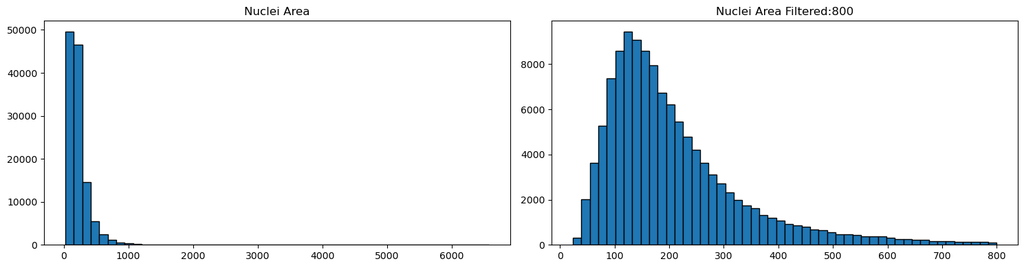

```python
# Store the area of each nucleus in the GeoDataframe
gdf['area'] = gdf['geometry'].area

# Calculate quality control metrics for the original AnnData object
sc.pp.calculate_qc_metrics(grouped_filtered_adata, inplace=True)

# Plot the nuclei area distribution before and after filtering
plot_nuclei_area(gdf=gdf,area_cut_off=800)
```

Based on the nuclei distribution we selected a value to filter the data.

Next we plot the total UMI distribution.

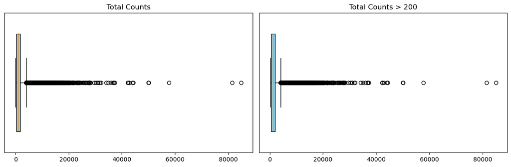

```python
# Plot total UMI distribution
total_umi(grouped_filtered_adata, 200)
```

The following code block filters the data.

```python
# Create a mask based on the 'id' column for values present in 'gdf' with 'area' less than 500
mask_area = grouped_filtered_adata.obs['id'].isin(gdf[gdf['area'] < 800].id)

# Create a mask based on the 'total_counts' column for values greater than 100
mask_count = grouped_filtered_adata.obs['total_counts'] > 200

# Apply both masks to the original AnnData to create a new filtered AnnData object
count_area_filtered_adata = grouped_filtered_adata[mask_area & mask_count, :]

# Calculate quality control metrics for the filtered AnnData object
sc.pp.calculate_qc_metrics(count_area_filtered_adata, inplace=True)
```

```
_qc.py (141): Trying to modify attribute `.obs` of view, initializing view as actual.
anndata.py (1756): Variable names are not unique. To make them unique, call `.var_names_make_unique`.
```

To assess the binning results, we examine gene expression and clustering. In the next block of code, the results undergo clustering. It is important to note that the resolution parameter used in Leiden clustering may need adjustment when working with different datasets.

```python
# Normalize total counts for each cell in the AnnData object
sc.pp.normalize_total(count_area_filtered_adata, inplace=True)

# Logarithmize the values in the AnnData object after normalization
sc.pp.log1p(count_area_filtered_adata)

# Identify highly variable genes in the dataset using the Seurat method
sc.pp.highly_variable_genes(count_area_filtered_adata, flavor="seurat", n_top_genes=2000)

# Perform Principal Component Analysis (PCA) on the AnnData object
sc.pp.pca(count_area_filtered_adata)

# Build a neighborhood graph based on PCA components
sc.pp.neighbors(count_area_filtered_adata)

# Perform Leiden clustering on the neighborhood graph and store the results in 'clusters' column

# Adjust the resolution parameter as needed for different samples
sc.tl.leiden(count_area_filtered_adata, resolution=0.35, key_added="clusters")
```

```
1117593883.py (19): In the future, the default backend for leiden will be igraph instead of leidenalg.

 To achieve the future defaults please pass: flavor="igraph" and n_iterations=2.  directed must also be False to work with igraph's implementation.
```

When the clustering results are plotted, we see clusters that align with morphological features.

```
Clipping input data to the valid range for imshow with RGB data ([0..1] for floats or [0..255] for integers). Got range [-0.22962964..1.2888889].
```

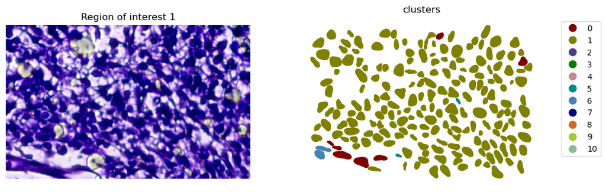

```python
# Plot and save the clustering results
plot_clusters_and_save_image(title="Region of interest 1", gdf=gdf, img=img, adata=count_area_filtered_adata, bbox=bbox, color_by_obs='clusters', output_name=dir_base+"image_clustering.ROI1.tiff")
```

Figure 3: Clustering results of custom nuclei binning.

```python
picklable_vars = get_picklable_objects(globals())
with open("ipynb_workspace.pkl", "wb") as f:
    pickle.dump(picklable_vars, f)
```

[output not shown]

## 4 Export 4 Seurat

```python
with open("ipynb_workspace.pkl", "rb") as f:
    picklable_vars = pickle.load(f)
globals().update(picklable_vars)
```

### 4.1 Export centroids

```python
# Calculate the centroid of each geometry in the GeoDataFrame
gdf['centroid'] = gdf.geometry.centroid

# Optionally, you can create a new GeoDataFrame with these centroids
centroid_gdf = gpd.GeoDataFrame(gdf, geometry=gdf['centroid'])

centroid_list = []
for _, row in centroid_gdf.iterrows():
    feature_id = row['id']  # Get the "id" column value from the GeoDataFrame
    centroid_x = row['centroid'].x  # Get the x-coordinate of the centroid
    centroid_y = row['centroid'].y  # Get the y-coordinate of the centroid

    # Append the result as a dictionary
    centroid_list.append({'id': feature_id, 'x': centroid_x, 'y': centroid_y})

# Convert the list to a DataFrame
centroid_df = pd.DataFrame(centroid_list)

# Display the first few rows to check
print(centroid_df.head())
```

```
     id            x            y
0  ID_1  2593.746705  3787.057754
1  ID_2  3310.244000  1873.873352
2  ID_3  2592.093351  3946.386041
3  ID_4  2584.403024  2870.861772
4  ID_5  2753.619473  2091.270473
```

```python
# Export centroid_df as a .txt file
centroid_df.to_csv('centroid_df.txt', sep='\t', index=False)
```

### 4.2 Export nucleus boundaries

```python
# Initialize an empty list to store the boundary coordinates
boundary_list = []

# Iterate over each row in the GeoDataFrame
for _, row in gdf.iterrows():
    feature_id = row['id']  # Get the "id" column value from the GeoDataFrame
    boundary_coords = row.geometry.boundary.coords  # Extract the boundary coordinates

    # Iterate through each boundary coordinate
    for coord in boundary_coords:
        boundary_list.append({'id': feature_id, 'x': coord[0], 'y': coord[1]})

# Convert the list of coordinates to a DataFrame
boundary_df = pd.DataFrame(boundary_list)

# Display the first few rows of the resulting DataFrame
print(boundary_df.head())
```

```
     id            x            y
0  ID_1  2601.542725  3788.000000
1  ID_1  2600.985840  3789.389648
2  ID_1  2600.459961  3790.675781
3  ID_1  2599.719727  3791.821777
4  ID_1  2598.864502  3792.864502
```

```python
# Export boundary_df as a .txt file (assuming boundary_df is already defined)
boundary_df.to_csv('boundary_df.txt', sep='\t', index=False)
```

### 4.3 Export molecules

```python
import pandas as pd
import anndata as ad
from joblib import Parallel, delayed
from tqdm import tqdm

# Load your AnnData object (assuming it's pre-loaded as count_area_filtered_adata)
# Example: count_area_filtered_adata = ad.read_h5ad('your_data.h5ad')

# Define the function to process each gene column
def process_gene(var_index):
    results = []
    gene = count_area_filtered_adata.var_names[var_index]

    # Extract the expression values for the gene across all cells
    gene_values = count_area_filtered_adata.X[:, var_index].toarray().flatten()

    # Find non-zero entries and their corresponding cell ids
    for obs_index, value in enumerate(gene_values):
        if value > 0:
            cell_id = count_area_filtered_adata.obs.index[obs_index]
            results.append({'id': cell_id, 'gene': gene})

    return results

# Use joblib's Parallel to speed up the processing, with tqdm for a progress bar
n_jobs = -1  # Use all available CPU cores
results = Parallel(n_jobs=n_jobs, backend="multiprocessing")(
    delayed(process_gene)(var_index) for var_index in tqdm(range(count_area_filtered_adata.n_vars), desc="Processing Genes")
)

# Flatten the list of results
flat_results = [item for sublist in results for item in sublist]

# Convert the results list to a DataFrame
results_df = pd.DataFrame(flat_results)

# Merge with centroid_df to get the "x" and "y" values for each "id"
merged_df = results_df.merge(centroid_df, on='id', how='left')

# Display the first few rows of the resulting DataFrame
print(merged_df.head())
```

```
          id  gene            x            y
0  ID_100035  Xkr4  7150.096863  9738.153445
1  ID_100045  Xkr4  9472.700672  9138.104588
2   ID_10006  Xkr4  6364.628150  2762.853652
3   ID_10018  Xkr4  6275.437050  2938.944269
4  ID_100205  Xkr4  8778.982349  7867.464813
```

```python
# Export merged_df as a .txt file
merged_df.to_csv('merged_df.txt', sep='\t', index=False)
```

### 4.4 Export the gene expression matrix as 10x HDF5 format

```python
import h5py
import numpy as np
from scipy.sparse import csr_matrix
from pathlib import Path

def write_10X_h5(adata, file):
    """Writes adata to a 10X-formatted h5 file.

    Note that this function is not fully tested and may not work for all cases.
    It will not write the following keys to the h5 file compared to 10X:
    '_all_tag_keys', 'pattern', 'read', 'sequence'

    Args:
        adata (AnnData object): AnnData object to be written.
        file (str): File name to be written to. If no extension is given, '.h5' is appended.

    Raises:
        FileExistsError: If file already exists.

    Returns:
        None
    """

    if '.h5' not in file: file = f'{file}.h5'
    if Path(file).exists():
        raise FileExistsError(f"There already is a file `{file}`.")
    def int_max(x):
        return int(max(np.floor(len(str(int(max(x)))) / 4), 1) * 4)
    def str_max(x):
        return max([len(i) for i in x])

    w = h5py.File(file, 'w')
    grp = w.create_group("matrix")
    grp.create_dataset("barcodes", data=np.array(adata.obs_names, dtype=f'|S{str_max(adata.obs_names)}'))
    grp.create_dataset("data", data=np.array(adata.X.data, dtype=f'<i{int_max(adata.X.data)}'))
    ftrs = grp.create_group("features")
    # this group will lack the following keys:
    # '_all_tag_keys', 'feature_type', 'genome', 'id', 'name', 'pattern', 'read', 'sequence'
    ftrs.create_dataset("feature_type", data=np.array(adata.var.feature_types, dtype=f'|S{str_max(adata.var.feature_types)}'))
    ftrs.create_dataset("genome", data=np.array(adata.var.genome, dtype=f'|S{str_max(adata.var.genome)}'))
    ftrs.create_dataset("id", data=np.array(adata.var.gene_ids, dtype=f'|S{str_max(adata.var.gene_ids)}'))
    ftrs.create_dataset("name", data=np.array(adata.var.index, dtype=f'|S{str_max(adata.var.index)}'))
    grp.create_dataset("indices", data=np.array(adata.X.indices, dtype=f'<i{int_max(adata.X.indices)}'))
    grp.create_dataset("indptr", data=np.array(adata.X.indptr, dtype=f'<i{int_max(adata.X.indptr)}'))
    grp.create_dataset("shape", data=np.array(list(adata.X.shape)[::-1], dtype=f'<i{int_max(adata.X.shape)}'))
```

```python
write_10X_h5(adata=count_area_filtered_adata, file="count_area_filtered_adata.h5")
```

```python
picklable_vars = get_picklable_objects(globals())
with open("ipynb_workspace.pkl", "wb") as f:
    pickle.dump(picklable_vars, f)
```

[output not shown]

End